# Mask Mandates & COVID-19

### Results: Model Output

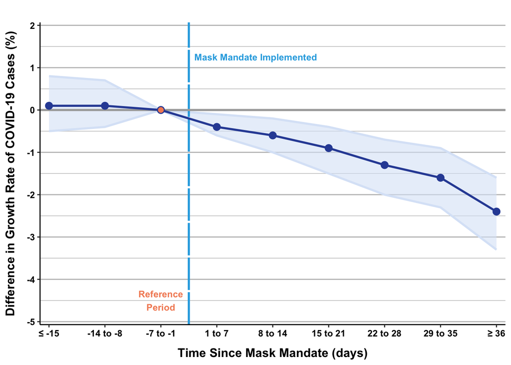

```r
# cases - GRAPH cases growth rate feols - ribbon - KEEP THIS ONE
{
# PAIR Colors" # Lapis Iazuli = #2F4DA4 | # Salmon = #F38C63 | # Lavender = #DAE6F7 | # BlueGreen = #2BABE2 |
# Penn Colors: # Red = #911123 | # Light Red = #FFE4E0 | # Blue = #002E5C | # Light Blue = #E4F0FF | # Aqua = #2BABE2

xlabels=c("≤ -15","-14 to -8","-7 to -1",
          "1 to 7","8 to 14","15 to 21","22 to 28","29 to 35","≥ 36")

g_coefplot_feols7_cases_med = d_coefplot_feols7_cases_med
g_coefplot_feols7_cases_med[c("y","estimate","ci_low","ci_high")] = round(g_coefplot_feols7_cases_med[c("y","estimate","ci_low","ci_high")]*100,1)

graph_coefplot_feols7_cases_med  =  ggplot(data=g_coefplot_feols7_cases_med,aes(x=x)) + theme_bw() +
                                    geom_ribbon(aes(y=y,ymin=ci_low,ymax=ci_high),fill="#DAE6F7",alpha=.6) +
                                    geom_line(aes(y=ci_low),color="#DAE6F7",size=1,) +
                                    geom_line(aes(y=ci_high),color="#DAE6F7",size=1) +
                                    # geom_errorbar(aes(y=y,ymin=ci_low,ymax=ci_high), width=0.15, size=0.55, color= "#2F4DA4") +
                                    geom_vline(xintercept=3.5,color="#2BABE2",linetype="F1",size=1) +
                                       annotate("text",x=3.6,y=1.25,label="Mask Mandate Implemented",color="#2BABE2",size=3.2,fontface="bold",hjust=0) +
                                    geom_hline(yintercept=0,color="Dark Grey",size=1) +
                                    geom_line(aes(y=y),size=1,color="#2F4DA4") +
                                    geom_point(aes(y=y),size=3,color="#2F4DA4") +
                                       geom_point(data=d_coefplot_feols7_cases_med %>% filter(is_ref=="TRUE"),aes(x=x,y=y),size=2,color="#F38C63") +
                                       annotate("text",x=3,y=-4.5,label="Reference\nPeriod",color="#F38C63",size=3.2,fontface="bold",hjust=0.5) +
                                    scale_y_continuous(breaks=seq(from=-5,to=2,by=1),expand=expansion(mult=c(0.01,0.01))) +
                                    scale_x_continuous(breaks=seq(from=1,to=9,by=1),labels=xlabels,expand=expansion(mult=c(0.02,0.02))) +
                                    coord_cartesian(ylim=c(-5,2),clip="off") +
                                    labs(title="",
                                         x="Time Since Mask Mandate (days)",
                                         y="Difference in Growth Rate of COVID-19 Cases (%)") +
                                    theme(panel.grid.minor.y=element_line(color="grey"), panel.grid.major.y=element_line(color="grey"),
                                          panel.grid.minor.x=element_blank(), panel.grid.major.x=element_blank(),
                                          panel.background=element_blank(),panel.border=element_blank()) +
                                    theme(plot.title=element_text(size=12,color="black",hjust=0.5,face="bold"),
                                          axis.title.y=element_text(size=12,color="black",hjust=0.5,face="bold",margin=margin(t=0,r=10,b=0,l=0)),
                                          axis.title.x=element_text(size=12,color="black",face="bold",margin=margin(t=10,r=0,b=00,l=0)),
                                          axis.text.y=element_text(size=9,color="black",face="bold"),
                                          axis.text.x=element_text(size=9,color="black",face="bold"),
                                          axis.line=element_line(color="black"))
print(graph_coefplot_feols7_cases_med)
# ggsave(filename="coefplot_feols7_cases_med.svg",plot=graph_coefplot_feols7_cases_med,
#        path="~/Google Drive/2020_Masks_EpiQualExam/Analysis_MaskMandate/4_Graphics/1_coefplot_feols7/", width = 10, height = 5)
}
```

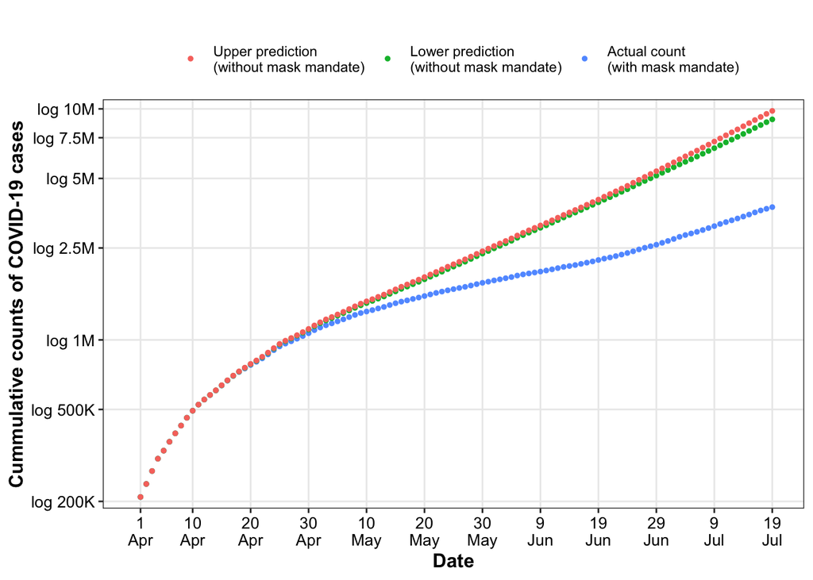

```r
# cases - GRAPH cases actual versus cases averted - KEEP THIS ONE
{
gDATA_cases_Prediction = DATA_cases_Prediction %>%
                         select(date_index,total_cases,predicted_lower_cases,predicted_upper_cases) %>%
                         pivot_longer(!date_index, names_to = "names",values_to = "counts")
gDATA_cases_Prediction$day = plyr::mapvalues(gDATA_cases_Prediction$date_index,from=dStudyRange$date_index,
                                                                               to=dStudyRange$day)
gDATA_cases_Prediction$month = plyr::mapvalues(gDATA_cases_Prediction$date_index,from=dStudyRange$date_index,
                                                                               to=dStudyRange$month)
gDATA_cases_Prediction$Mon = plyr::mapvalues(gDATA_cases_Prediction$month,from=c(1:length(month.abb)),
                                                                               to=month.abb)
gDATA_cases_Prediction$day_Mon = paste0(gDATA_cases_Prediction$day,"\n",gDATA_cases_Prediction$Mon)

x_labels = gDATA_cases_Prediction %>% filter(date_index %in% c(1,seq(from=10, to=110, by = 10))) %>%
                                      dplyr::select(date_index,day_Mon) %>%
                                      distinct()
gDATA_cases_Prediction$names = factor(gDATA_cases_Prediction$names,
                                             levels=c("predicted_upper_cases",
                                                      "predicted_lower_cases",
                                                      "total_cases"),
                                             labels=c("Upper prediction\n(without mask mandate)",
                                                      "Lower prediction\n(without mask mandate)",
                                                      "Actual count \n(with mask mandate)"))

ylims_log = c(200000, 500000, 1000000, 2500000, 5000000, 7500000, 10000000)
ylabels_log = c("log 200K","log 500K","log 1M", "log 2.5M","log 5M", "log 7.5M","log 10M")

graph_cases_Prediction = ggplot(data=gDATA_cases_Prediction,aes(x=date_index,y=counts,color=names)) + theme_bw() +
                  scale_y_continuous(trans="log10",breaks=ylims_log,labels=ylabels_log,expand=expansion(mult=c(.03,.03))) +
                  scale_x_continuous(breaks=c(1,seq(from=10, to=110, by = 10)), labels=x_labels$day_Mon) +
                  coord_cartesian(xlim=c(0,110)) +
                  geom_point(size=1) +
                  # ggrepel::geom_text_repel(data=gDATA_cases_Prediction %>%
                  #                 filter(date_index==110),
                  #                 aes(x=date_index,y=counts,label=paste(names,": ",format(round(as.numeric(counts), 0), big.mark=",")
                  #                                                      ,sep="")),
                  #                 force=1, point.padding=unit(1,'lines'), direction = 'both', nudge_x = 5, nudge_y = 0, hjust=0,
                  #                 size=2.5, segment.size=.05, show.legend=FALSE) +
                  labs(title="",
                       y="Cummulative counts of COVID-19 cases",
                       x="Date") +
                  theme(plot.title=element_text(size=12,color="black",hjust=0.5,face="bold"),
                        axis.title.x=element_text(size=12,color="black",face="bold"),
                        axis.title.y=element_text(size=12,color="black",face="bold"),
                        axis.text.x=element_text(size=10,color="black"),
                        axis.text.y=element_text(size=10,color="black")) +
                  theme(panel.grid.minor=element_blank()) +
                  theme(legend.position="top", legend.title=element_blank())
print(graph_cases_Prediction)
}
```

```r
cat(paste0("05/22/2020 | 1,597,220 actual cases and ",
           format(round(cases_predict_day52_lower,0), nsmall=0, big.mark=","),
           " - ",
           format(round(cases_predict_day52_upper,0), nsmall=0, big.mark=","),
           " cases were averted\n"))
```

```
## 05/22/2020 | 1,597,220 actual cases and 326,222 - 370,388 cases were averted
```

```r
cat(paste0("07/19/2020 | 3,755,800 actual cases and ",
           format(round(cases_predict_day110_lower,0), nsmall=0, big.mark=","),
           " - ",
           format(round(cases_predict_day110_upper,0), nsmall=0, big.mark=","),
           " cases were averted\n"))
```

```
## 07/19/2020 | 3,755,800 actual cases and 5,249,232 - 6,042,554 cases were averted
```

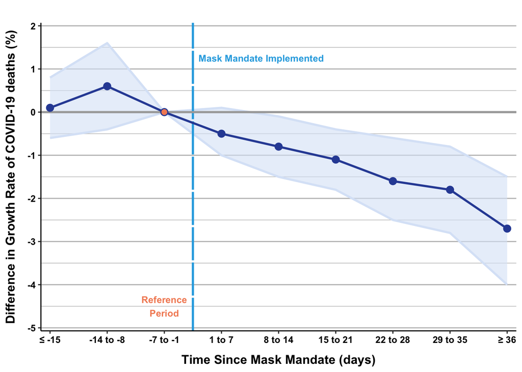

```r
# deaths - GRAPH deaths growth rate feols - ribbon - KEEP THIS ONE
{
# PAIR Colors" # Lapis Iazuli = #2F4DA4 | # Salmon = #F38C63 | # Lavender = #DAE6F7 | # BlueGreen = #2BABE2 |
# Penn Colors: # Red = #911123 | # Light Red = #FFE4E0 | # Blue = #002E5C | # Light Blue = #E4F0FF | # Aqua = #2BABE2

xlabels=c("≤ -15","-14 to -8","-7 to -1",
          "1 to 7","8 to 14","15 to 21","22 to 28","29 to 35","≥ 36")

g_coefplot_feols7_deaths_med = d_coefplot_feols7_deaths_med
g_coefplot_feols7_deaths_med[c("y","estimate","ci_low","ci_high")] = round(g_coefplot_feols7_deaths_med[c("y","estimate","ci_low","ci_high")]*100,1)

graph_coefplot_feols7_deaths_med =  ggplot(data=g_coefplot_feols7_deaths_med,aes(x=x)) + theme_bw() +
                                    geom_ribbon(aes(y=y,ymin=ci_low,ymax=ci_high),fill="#DAE6F7",alpha=.6) +
                                    geom_line(aes(y=ci_low),color="#DAE6F7",size=1,) +
                                    geom_line(aes(y=ci_high),color="#DAE6F7",size=1) +
                                    # geom_errorbar(aes(y=y,ymin=ci_low,ymax=ci_high), width=0.15, size=0.55, color= "#2F4DA4") +
                                    geom_vline(xintercept=3.5,color="#2BABE2",linetype="F1",size=1) +
                                       annotate("text",x=3.6,y=1.25,label="Mask Mandate Implemented",color="#2BABE2",size=3.2,fontface="bold",hjust=0) +
                                    geom_hline(yintercept=0,color="Dark Grey",size=1) +
                                    geom_line(aes(y=y),size=1,color="#2F4DA4") +
                                    geom_point(aes(y=y),size=3,color="#2F4DA4") +
                                       geom_point(data=d_coefplot_feols7_deaths_med %>% filter(is_ref=="TRUE"),aes(x=x,y=y),size=2,color="#F38C63") +
                                       annotate("text",x=3,y=-4.5,label="Reference\nPeriod",color="#F38C63",size=3.2,fontface="bold",hjust=0.5) +
                                    scale_y_continuous(breaks=seq(from=-5,to=2,by=1),expand=expansion(mult=c(0.01,0.01))) +
                                    scale_x_continuous(breaks=seq(from=1,to=9,by=1),labels=xlabels,expand=expansion(mult=c(0.02,0.02))) +
                                    coord_cartesian(ylim=c(-5,2),clip="off") +
                                    labs(title="",
                                         x="Time Since Mask Mandate (days)",
                                         y="Difference in Growth Rate of COVID-19 deaths (%)") +
                                    theme(panel.grid.minor.y=element_line(color="grey"), panel.grid.major.y=element_line(color="grey"),
                                          panel.grid.minor.x=element_blank(), panel.grid.major.x=element_blank(),
                                          panel.background=element_blank(),panel.border=element_blank()) +
                                    theme(plot.title=element_text(size=12,color="black",hjust=0.5,face="bold"),
                                          axis.title.y=element_text(size=12,color="black",hjust=0.5,face="bold",margin=margin(t=0,r=10,b=0,l=0)),
                                          axis.title.x=element_text(size=12,color="black",face="bold",margin=margin(t=10,r=0,b=00,l=0)),
                                          axis.text.y=element_text(size=9,color="black",face="bold"),
                                          axis.text.x=element_text(size=9,color="black",face="bold"),
                                          axis.line=element_line(color="black"))
print(graph_coefplot_feols7_deaths_med)
# ggsave(filename="coefplot_feols7_deaths_med.svg",plot=graph_coefplot_feols7_deaths_med,
#        path="~/Google Drive/2020_Masks_EpiQualExam/Analysis_MaskMandate/4_Graphics/1_coefplot_feols7/", width = 10, height = 5)
}
```

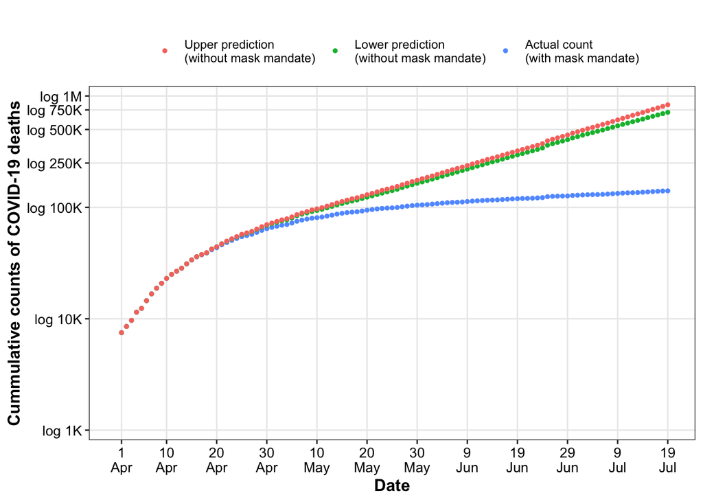

```r
# deaths - GRAPH deaths actual versus deaths averted - KEEP THIS ONE
{
gDATA_deaths_Prediction = DATA_deaths_Prediction %>%
                         select(date_index,total_deaths,predicted_lower_deaths,predicted_upper_deaths) %>%
                         pivot_longer(!date_index, names_to = "names",values_to = "counts")
gDATA_deaths_Prediction$day = plyr::mapvalues(gDATA_deaths_Prediction$date_index,from=dStudyRange$date_index,
                                                                               to=dStudyRange$day)
gDATA_deaths_Prediction$month = plyr::mapvalues(gDATA_deaths_Prediction$date_index,from=dStudyRange$date_index,
                                                                               to=dStudyRange$month)
gDATA_deaths_Prediction$Mon = plyr::mapvalues(gDATA_deaths_Prediction$month,from=c(1:length(month.abb)),
                                                                               to=month.abb)
gDATA_deaths_Prediction$day_Mon = paste0(gDATA_deaths_Prediction$day,"\n",gDATA_deaths_Prediction$Mon)

x_labels = gDATA_deaths_Prediction %>% filter(date_index %in% c(1,seq(from=10, to=110, by = 10))) %>%
                                      dplyr::select(date_index,day_Mon) %>%
                                      distinct()
gDATA_deaths_Prediction$names = factor(gDATA_deaths_Prediction$names,
                                             levels=c("predicted_upper_deaths",
                                                      "predicted_lower_deaths",
                                                      "total_deaths"),
                                             labels=c("Upper prediction\n(without mask mandate)",
                                                      "Lower prediction\n(without mask mandate)",
                                                      "Actual count \n(with mask mandate)"))

ylims_log = c(1000, 10000, 100000, 250000, 500000, 750000, 1000000)
ylabels_log = c("log 1K","log 10K", "log 100K", "log 250K", "log 500K", "log 750K","log 1M")

graph_deaths_Prediction = ggplot(data=gDATA_deaths_Prediction,aes(x=date_index,y=counts,color=names)) + theme_bw() +
                  scale_y_continuous(trans="log10",breaks=ylims_log,labels=ylabels_log,expand=expansion(mult=c(.03,.03))) +
                  scale_x_continuous(breaks=c(1,seq(from=10, to=110, by = 10)), labels=x_labels$day_Mon) +
                  coord_cartesian(xlim=c(0,110), ylim=c(1000,1000000)) +
                  geom_point(size=1) +
                  # ggrepel::geom_text_repel(data=gDATA_deaths_Prediction %>%
                  #                 filter(date_index==110),
                  #                 aes(x=date_index,y=counts,label=paste(names,": ",format(round(as.numeric(counts), 0), big.mark=",")
                  #                                                      ,sep="")),
                  #                 force=1, point.padding=unit(1,'lines'), direction = 'both', nudge_x = 5, nudge_y = 0, hjust=0,
                  #                 size=2.5, segment.size=.05, show.legend=FALSE) +
                  labs(title="",
                       y="Cummulative counts of COVID-19 deaths",
                       x="Date") +
                  theme(plot.title=element_text(size=12,color="black",hjust=0.5,face="bold"),
                        axis.title.x=element_text(size=12,color="black",face="bold"),
                        axis.title.y=element_text(size=12,color="black",face="bold"),
                        axis.text.x=element_text(size=10,color="black"),
                        axis.text.y=element_text(size=10,color="black")) +
                  theme(panel.grid.minor=element_blank()) +
                  theme(legend.position="top",legend.title=element_blank())
print(graph_deaths_Prediction)
}
```

```r
cat(paste0("05/22/2020 | 96,880 actual deaths and ",
           format(round(deaths_predict_day52_lower,0), nsmall=0, big.mark=","),
           " - ",
           format(round(deaths_predict_day52_upper,0), nsmall=0, big.mark=","),
           " deaths averted\n"))
```

```
## 05/22/2020 | 96,880 actual deaths and 33,567 - 40,833 deaths averted
```

```r
cat(paste0("07/19/2020 | 133,514 actual deaths and ",
           format(round(deaths_predict_day110_lower,0), nsmall=0, big.mark=","),
           " - ",
           format(round(deaths_predict_day110_upper,0), nsmall=0, big.mark=","),
           " deaths averted\n"))
```

[output not shown]

### **Conclusion**

- We found that mask mandates are associated with decreases in the growth rate as well as the cumulative counts of COVID-19 cases and deaths. Specifically, our study demonstrates that the piecemeal, state-by-state decisions for implementing statewide mask mandates likely resulted in countless averted COVID-19 cases and deaths.
- Our immediate, next steps are to explore effect modification by county-level political partisanship, poverity rates, and urban-rural designation. These variables have already been imported and merged into our final dataset.
- The strengths of our study are that it is generalizable to U.S. population and is relatively cost effective in terms of time, money, and personnel involvement.
- Our study has several limitations. First, it is a natural experiment or commonly known an observational study. Thus, our findings may suggest associations between the exposure and outcome, but we cannot make inferences about any causal relationships with futher exploration. Second, our study assumes universal mask availability and mask compliance in states with mask mandates, which is most likely not true. Third, our outcome is at the county level so we are unable to make inferences about the effect of masking at a personal level. Lastly, the outcome is derived from confirmed COVID-19 cases, but our findings would presumably be larger if we were able to include all COVID-19 cases.
- Nonetheless, our findings support the implementation of a national mask mandate which has already been proposed by the incoming Biden-Harris administration. Additionally, our work supports an existing body of research and health policies advocating for universal masking among the public. Although COVID-19 vaccinations have begun, policies and efforts promoting masking in public settings will continue to slow the transmission of COVID-19 particularly among the overwhelming majority of unvaccinated individuals who eagerly await vaccination.